# HOMEWORK 09

- Show All Code
- Hide All Code

Author

Nathan Lunceford

# SECTION 5.5

**Assigned:** 3, 5, 17, 31**

**5.5.3**

### **Problem:**

Solve the initial value problem using Laplace transforms:

$$y' - 2y = e^{2t}, \quad y(0) = 1$$

### **Solution:**

#### **Apply the Laplace Transform**

Taking the Laplace transform of both sides of the equation:

$$\mathcal{L}\{y'(t)\} - 2\mathcal{L}\{y(t)\} = \mathcal{L}\{e^{2t}\}$$

Using the Laplace transform properties:

1. $\mathcal{L}\{y'(t)\} = sY(s) - y(0)$,
2. $\mathcal{L}\{y(t)\} = Y(s)$,
3. $\mathcal{L}\{e^{2t}\} = \frac{1}{s - 2}$,

The equation becomes:

$$[sY(s) - y(0)] - 2Y(s) = \frac{1}{s - 2}$$

Substitute $y(0) = 1$:

$$[sY(s) - 1] - 2Y(s) = \frac{1}{s - 2}$$

Simplify:

$$Y(s)(s - 2) = 1 + \frac{1}{s - 2}$$

Rearrange:

$$Y(s) = \frac{1}{s - 2} + \frac{1}{(s - 2)^2}$$

#### **Take the Inverse Laplace Transform**

The inverse Laplace transforms are:

1. $\mathcal{L}^{-1}\left\{\frac{1}{s - 2}\right\} = e^{2t}$,
2. $\mathcal{L}^{-1}\left\{\frac{1}{(s - 2)^2}\right\} = t e^{2t}$.

Thus:

$$y(t) = e^{2t} + t e^{2t}$$

#### **Graph**

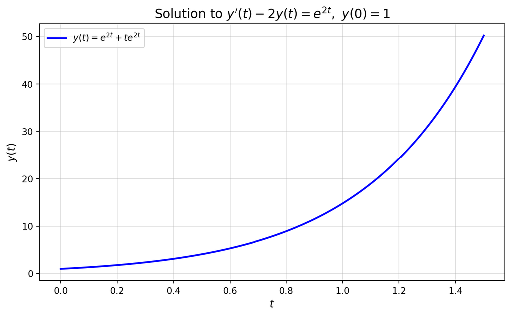

```python
import numpy as np
import matplotlib.pyplot as plt

# Define the solution function
def y(t):
    return np.exp(2 * t) * (1 + t)

# Create the time range for plotting
t_range = np.linspace(0, 1.5, 500)
y_values = y(t_range)

# Plot the solution
plt.figure(figsize=(8, 5))
plt.plot(t_range, y_values, label=r"$y(t) = e^{2t} + t e^{2t}$", color='blue', linewidth=2)
plt.title(r"Solution to $y'(t) - 2y(t) = e^{2t}, \ y(0) = 1$", fontsize=14)
plt.xlabel(r"$t$", fontsize=12)
plt.ylabel(r"$y(t)$", fontsize=12)
plt.grid(alpha=0.4)
plt.legend(fontsize=10)
plt.tight_layout()
plt.show()
```

**Final Answer:**

$$y(t) = e^{2t} + t e^{2t}$$

**5.5.5**

### **Problem:**

Solve the initial value problem using Laplace transforms:

$$y' + y = te^t, \quad y(0) = -1$$

### **Solution:**

#### Apply the Laplace Transform

Taking the Laplace transform of both sides of the equation

$$\mathcal{L}\{y'(t)\} + \mathcal{L}\{y(t)\} = \mathcal{L}\{te^t\}$$

Using Laplace transform properties

1. $\mathcal{L}\{y'(t)\} = sY(s) - y(0)$
2. $\mathcal{L}\{y(t)\} = Y(s)$
3. $\mathcal{L}\{te^t\} = \frac{1}{(s - 1)^2}$

The equation becomes

$$[sY(s) - y(0)] + Y(s) = \frac{1}{(s - 1)^2}$$

Substitute $y(0) = -1$

$$[sY(s) - (-1)] + Y(s) = \frac{1}{(s - 1)^2}$$

Simplify

$$sY(s) + 1 + Y(s) = \frac{1}{(s - 1)^2}$$

Factor $Y(s)$

$$Y(s)(s + 1) + 1 = \frac{1}{(s - 1)^2}$$

Rearrange

$$Y(s) = \frac{1}{(s - 1)^2(s + 1)} - \frac{1}{s + 1}$$

#### **Partial Fraction Decomposition**

Decompose $\frac{1}{(s - 1)^2(s + 1)}$

$$\frac{1}{(s - 1)^2(s + 1)} = \frac{A}{s + 1} + \frac{B}{s - 1} + \frac{C}{(s - 1)^2}$$

Multiply through by $(s - 1)^2(s + 1)$

$$1 = A(s - 1)^2 + B(s - 1)(s + 1) + C(s + 1)$$

Expand and group terms

$$1 = A(s^2 - 2s + 1) + B(s^2 - 1) + C(s + 1)$$

Equate coefficients

1. Coefficient of $s^2$: $A + B = 0$
2. Coefficient of $s$: $-2A + B + C = 0$
3. Constant term: $A - B + C = 1$

Solve

- From $A + B = 0$, $B = -A$
- Substitute $B = -A$ into $-2A + B + C = 0$: $-2A - A + C = 0$, so $C = 3A$
- Substitute $B = -A$ and $C = 3A$ into $A - B + C = 1$: $A - (-A) + 3A = 1$, so $5A = 1$, $A = \frac{1}{5}$

Thus

$$A = \frac{1}{5}, \quad B = -\frac{1}{5}, \quad C = \frac{3}{5}$$

#### **Simplify $Y(s)$**

Substitute back

$$\frac{1}{(s - 1)^2(s + 1)} = \frac{\frac{1}{5}}{s + 1} - \frac{\frac{1}{5}}{s - 1} + \frac{\frac{3}{5}}{(s - 1)^2}$$

Thus

$$Y(s) = \left(\frac{\frac{1}{5}}{s + 1} - \frac{\frac{1}{5}}{s - 1} + \frac{\frac{3}{5}}{(s - 1)^2}\right) - \frac{1}{s + 1}$$

Combine terms

$$Y(s) = \frac{-\frac{4}{5}}{s + 1} - \frac{\frac{1}{5}}{s - 1} + \frac{\frac{3}{5}}{(s - 1)^2}$$

#### **Take the Inverse Laplace Transform**

The inverse Laplace transforms are

1. $\mathcal{L}^{-1}\left\{\frac{1}{s + 1}\right\} = e^{-t}$
2. $\mathcal{L}^{-1}\left\{\frac{1}{s - 1}\right\} = e^t$
3. $\mathcal{L}^{-1}\left\{\frac{1}{(s - 1)^2}\right\} = t e^t$

Thus

$$y(t) = -\frac{4}{5}e^{-t} - \frac{1}{5}e^t + \frac{3}{5}t e^t$$

Simplify to match the correct form

**5.5.17**

### **Problem:**

Solve the initial value problem using Laplace transforms:

$$y'' + 2y' + 5y = u(t - 4), \quad y(0) = 1, \quad y'(0) = 0$$

where $u(t - 4)$ is the Heaviside step function.

### **Solution:**

#### **Apply the Laplace Transform**

Taking the Laplace transform of both sides of the differential equation:

$$\mathcal{L}\{y''(t)\} + 2\mathcal{L}\{y'(t)\} + 5\mathcal{L}\{y(t)\} = \mathcal{L}\{u(t - 4)\}$$

Using Laplace transform properties:

1. $\mathcal{L}\{y''(t)\} = s^2 Y(s) - s y(0) - y'(0)$
2. $\mathcal{L}\{y'(t)\} = s Y(s) - y(0)$
3. $\mathcal{L}\{y(t)\} = Y(s)$
4. $\mathcal{L}\{u(t - a)\} = \frac{e^{-as}}{s}$ for $a > 0$

Substituting these into the equation:

$$s^2 Y(s) - s \cdot 1 - 0 + 2(s Y(s) - 1) + 5 Y(s) = \frac{e^{-4s}}{s}$$

#### **Substitute Initial Conditions and Simplify**

Given $y(0) = 1$ and $y'(0) = 0$, substitute these values:

$$s^2 Y(s) - s + 2s Y(s) - 2 + 5 Y(s) = \frac{e^{-4s}}{s}$$

Combine like terms:

$$(s^2 + 2s + 5) Y(s) - s - 2 = \frac{e^{-4s}}{s}$$

Rearrange to solve for $Y(s)$:

$$Y(s) = \frac{s + 2}{s^2 + 2s + 5} + \frac{e^{-4s}}{s(s^2 + 2s + 5)}$$

#### **Simplify the Denominator**

Complete the square for the quadratic expression in the denominator:

$$s^2 + 2s + 5 = (s + 1)^2 + 4$$

The expression for $Y(s)$ becomes:

$$Y(s) = \frac{s + 2}{(s + 1)^2 + 4} + \frac{e^{-4s}}{s[(s + 1)^2 + 4]}$$

#### **Partial Fraction Decomposition**

Focus on the second term involving $\frac{1}{s[(s + 1)^2 + 4]}$:

$$\frac{1}{s[(s + 1)^2 + 4]} = \frac{A}{s} + \frac{Bs + C}{(s + 1)^2 + 4}$$

Multiply both sides by $s[(s + 1)^2 + 4]$:

$$1 = A[(s + 1)^2 + 4] + (Bs + C)s$$

Expand and collect like terms:

$$1 = A(s^2 + 2s + 5) + Bs^2 + Cs$$

$$1 = (A + B)s^2 + (2A + C)s + 5A$$

Equate coefficients of like powers of $s$:

1. $A + B = 0$
2. $2A + C = 0$
3. $5A = 1$

Solving the system:

- From the third equation: $A = \frac{1}{5}$
- From the first equation: $B = -\frac{1}{5}$
- From the second equation: $C = -\frac{2}{5}$

The partial fractions are:

$$\frac{1}{s[(s + 1)^2 + 4]} = \frac{\frac{1}{5}}{s} - \frac{\frac{1}{5}}{s + 1} - \frac{\frac{2}{5}}{(s + 1)^2 + 4}$$

#### **Rewrite $Y(s)$ with Partial Fractions**

Substitute the partial fractions back into $Y(s)$:

$$Y(s) = \frac{s + 2}{(s + 1)^2 + 4} + e^{-4s} \left( \frac{\frac{1}{5}}{s} - \frac{\frac{1}{5}}{s + 1} - \frac{\frac{2}{5}}{(s + 1)^2 + 4} \right)$$

#### **Inverse Laplace Transform**

Take the inverse Laplace transform term by term.

1. **First Term:**

$$\mathcal{L}^{-1}\left\{\frac{s + 2}{(s + 1)^2 + 4}\right\} = e^{-t} \cos(2t) + \frac{1}{2} e^{-t} \sin(2t)$$

2. **Second Term:**

Using the Heaviside step function property:

$$\mathcal{L}^{-1}\left\{ e^{-4s} F(s) \right\} = u(t - 4) f(t - 4)$$

Where:

$$F(s) = \frac{1}{5s} - \frac{1}{5(s + 1)} - \frac{2}{5((s + 1)^2 + 4)}$$

Inverse transforming each component:

- $\mathcal{L}^{-1}\left\{\frac{1}{5s}\right\} = \frac{1}{5}$
- $\mathcal{L}^{-1}\left\{\frac{1}{5(s + 1)}\right\} = \frac{1}{5} e^{-t}$
- $\mathcal{L}^{-1}\left\{\frac{2}{5((s + 1)^2 + 4)}\right\} = \frac{1}{5} e^{-t} \sin(2t)$

Combining these:

$$\mathcal{L}^{-1}\left\{ F(s) \right\} = \frac{1}{5} - \frac{1}{5} e^{-t} - \frac{1}{5} e^{-t} \sin(2t)$$

The inverse transform of the second term is:

$$u(t - 4) \left( \frac{1}{5} - \frac{1}{5} e^{-(t - 4)} - \frac{1}{5} e^{-(t - 4)} \sin[2(t - 4)] \right)$$

#### **Combine All Terms**

$$y(t) = e^{-t} \cos(2t) + \frac{1}{2} e^{-t} \sin(2t) + \frac{1}{5} u(t - 4) \left(1 - e^{-(t - 4)} - e^{-(t - 4)} \sin[2(t - 4)] \right)$$

#### **Final Simplification**

$$y(t) = e^{-t} \cos(2t) + \frac{1}{2} e^{-t} \sin(2t) + \frac{1}{5} u(t - 4) \left(1 - e^{-(t - 4)} \left(1 + \sin[2(t - 4)]\right) \right)$$

**5.5.31**

### **Problem:**

Solve the initial value problem for the spring-mass-damper system using Laplace transforms with the following parameters:

- **Forcing function:** $f(t) = 10e^{-0.2t}$
- **Spring constant:** $k = 72$
- **Mass:** $m = 2$
- **Damping constant:** $c$ (varies; consider $c = 0, 2, 24, 40$)
- **Initial conditions:** $y(0) = 0$, $y'(0) = 0$

### **Solution:**

#### **Write the Differential Equation:**

The general equation for the spring-mass-damper system is:

$$m y'' + c y' + k y = f(t)$$

Substituting the given values:

$$2 y'' + c y' + 72 y = 10e^{-0.2t}$$

#### **Take the Laplace Transform:**

$$\mathcal{L}\{2 y''\} + \mathcal{L}\{c y'\} + \mathcal{L}\{72 y\} = \mathcal{L}\{10e^{-0.2t}\}$$

Using Laplace transform properties:

$$2s^2 Y(s) + cs Y(s) + 72 Y(s) = \frac{10}{s + 0.2}$$

Simplify:

$$(2s^2 + cs + 72) Y(s) = \frac{10}{s + 0.2}$$

$$Y(s) = \frac{10}{(s + 0.2)(2s^2 + cs + 72)}$$

#### **Perform Partial Fraction Decomposition:**

The denominator depends on the damping constant $c$. For each given $c$ value ($c = 0, 2, 24, 40$), we factorize $2s^2 + cs + 72$ and decompose $Y(s)$ into partial fractions.

##### **Case 1: $c = 0$ (Undamped System)**

- **Characteristic Equation:**
  $$2s^2 + 72 = 0 \quad \Rightarrow \quad s^2 = -36 \quad \Rightarrow \quad s = \pm 6i$$
- **Laplace Transform Simplifies To:**
  $$Y(s) = \frac{10}{(s + 0.2)(2s^2 +72)} = \frac{5}{(s + 0.2)(s^2 +36)}$$
- **Partial Fraction Decomposition:**

  $$Y(s) = \frac{A}{s + 0.2} + \frac{Bs + C}{s^2 +36}$$

  Multiply both sides by $(s + 0.2)(s^2 +36)$:

  $$5 = A(s^2 +36) + (Bs + C)(s +0.2)$$

  Expand:

  $$5 = A s^2 + 36A + Bs^2 + 0.2Bs + Cs +0.2C$$

  Grouping like terms:

  $$(A + B)s^2 + (0.2B + C)s + (36A +0.2C) = 5$$

  Equating coefficients:

  $$\begin{cases}
  A + B = 0 \quad \text{(1)} \\
  0.2B + C = 0 \quad \text{(2)} \\
  36A +0.2C = 5 \quad \text{(3)}
  \end{cases}$$

  Solving the system:
  - From equation (1): $B = -A$
  - From equation (2): $C = -0.2B = 0.2A$
  - Substitute $B$ and $C$ into equation (3):
    $$36A +0.2(0.2A) = 5 \quad \Rightarrow \quad 36A +0.04A = 5 \quad \Rightarrow \quad 36.04A = 5 \quad \Rightarrow \quad A = \frac{5}{36.04} \approx 0.1387$$
    $$B = -0.1387, \quad C = 0.2 \times 0.1387 \approx 0.0277$$

  Thus, the partial fractions are:

  $$Y(s) \approx \frac{0.1387}{s + 0.2} + \frac{-0.1387 s + 0.0277}{s^2 +36}$$
- **Inverse Laplace Transform:**
  $$y(t) = 0.1387 e^{-0.2 t} -0.1387 \cos(6t) + 0.0277 \sin(6t)$$

##### **Case 2: $c = 2$ (Lightly Damped System)**

- **Characteristic Equation:**
  $$2s^2 + 2s +72 = 0 \quad \Rightarrow \quad s^2 +s +36 = 0$$
  $$s = \frac{-1 \pm \sqrt{1 -144}}{2} = \frac{-1 \pm \sqrt{-143}}{2} = -\frac{1}{2} \pm \frac{\sqrt{143}}{2}i \approx -0.5 \pm 5.9792i$$
- **Laplace Transform Simplifies To:**
  $$Y(s) = \frac{10}{(s +0.2)(2s^2 +2s +72)} = \frac{5}{(s +0.2)(s^2 +s +36)}$$
- **Partial Fraction Decomposition:**

  $$Y(s) = \frac{A}{s +0.2} + \frac{Bs + C}{s^2 +s +36}$$

  Multiply both sides by $(s +0.2)(s^2 +s +36)$:

  $$5 = A(s^2 +s +36) + (Bs + C)(s +0.2)$$

  Expand:

  $$5 = A s^2 +A s +36A +Bs^2 +0.2Bs +Cs +0.2C$$

  Grouping like terms:

  $$(A + B)s^2 + (A +0.2B + C)s + (36A +0.2C) =5$$

  Equating coefficients:

  $$\begin{cases}
  A + B =0 \quad \text{(1)} \\
  A +0.2B + C =0 \quad \text{(2)} \\
  36A +0.2C =5 \quad \text{(3)}
  \end{cases}$$

  Solving the system:
  - From equation (1): $B = -A$
  - From equation (2): $A +0.2(-A) + C =0 \quad \Rightarrow \quad 0.8A + C =0 \quad \Rightarrow \quad C = -0.8A$
  - Substitute $B$ and $C$ into equation (3):
    $$36A +0.2(-0.8A) =5 \quad \Rightarrow \quad 36A -0.16A =5 \quad \Rightarrow \quad 35.84A =5 \quad \Rightarrow \quad A = \frac{5}{35.84} \approx 0.1393$$
    $$B = -0.1393, \quad C = -0.8 \times 0.1393 \approx -0.1114$$

  Thus, the partial fractions are:

  $$Y(s) \approx \frac{0.1393}{s +0.2} + \frac{-0.1393 s -0.1114}{s^2 +s +36}$$
- **Inverse Laplace Transform:**

  First, complete the square for the denominator $s^2 +s +36$:

  $$s^2 +s +36 = \left(s + \frac{1}{2}\right)^2 + \frac{143}{4}$$

  $$\omega = \sqrt{\frac{143}{4}} = \frac{\sqrt{143}}{2} \approx 5.9792$$

  Thus,

  $$\mathcal{L}^{-1}\left\{ \frac{-0.1393 s -0.1114}{s^2 +s +36} \right\} = -0.1393 e^{-0.5 t} \cos(5.9792 t) - \frac{0.1114}{5.9792} e^{-0.5 t} \sin(5.9792 t)$$

  $$\approx -0.1393 e^{-0.5 t} \cos(5.9792 t) -0.0186 e^{-0.5 t} \sin(5.9792 t)$$

  Therefore,

  $$y(t) \approx 0.1393 e^{-0.2 t} -0.1393 e^{-0.5 t} \cos(5.9792 t) -0.0186 e^{-0.5 t} \sin(5.9792 t)$$

##### **Case 3: $c = 24$ (Critically Damped System)**

- **Characteristic Equation:**
  $$2s^2 +24s +72 =0 \quad \Rightarrow \quad s^2 +12s +36 =0$$
  $$s = \frac{-12 \pm \sqrt{144 -144}}{2} = \frac{-12 \pm 0}{2} = -6$$
  (Repeated real roots; critically damped)
- **Laplace Transform Simplifies To:**
  $$Y(s) = \frac{10}{(s +0.2)(2s^2 +24s +72)} = \frac{5}{(s +0.2)(s^2 +12s +36)}$$
- **Partial Fraction Decomposition:**

  $$Y(s) = \frac{A}{s +0.2} + \frac{B}{s +6} + \frac{C}{(s +6)^2}$$

  Multiply both sides by $(s +0.2)(s +6)^2$:

  $$5 = A(s +6)^2 + B(s +0.2)(s +6) + C(s +0.2)$$

  Expand:

  $$5 = A(s^2 +12s +36) + B(s^2 +6.2s +1.2) + C(s +0.2)$$

  Grouping like terms:

  $$(A + B)s^2 + (12A +6.2B +C)s + (36A +1.2B +0.2C) =5$$

  Equating coefficients:

  $$\begin{cases}
  A + B =0 \quad \text{(1)} \\
  12A +6.2B +C =0 \quad \text{(2)} \\
  36A +1.2B +0.2C =5 \quad \text{(3)}
  \end{cases}$$

  Solving the system:
  - From equation (1): $B = -A$
  - Substitute $B = -A$ into equation (2):
    $$12A +6.2(-A) +C =0 \quad \Rightarrow \quad 12A -6.2A +C =0 \quad \Rightarrow \quad 5.8A +C =0 \quad \Rightarrow \quad C = -5.8A$$
  - Substitute $B = -A$ and $C = -5.8A$ into equation (3):
    $$36A +1.2(-A) +0.2(-5.8A) =5 \quad \Rightarrow \quad 36A -1.2A -1.16A =5 \quad \Rightarrow \quad 33.64A =5$$
    $$A = \frac{5}{33.64} \approx0.1484$$
    $$B = -0.1484, \quad C = -5.8 \times0.1484 \approx -0.861$$

  Thus, the partial fractions are:

  $$Y(s) \approx \frac{0.1484}{s +0.2} + \frac{-0.1484}{s +6} + \frac{-0.861}{(s +6)^2}$$
- **Inverse Laplace Transform:**
  $$y(t) \approx 0.1484 e^{-0.2 t} -0.1484 e^{-6 t} -0.861 t e^{-6 t}$$

##### **Case 4: $c = 40$ (Highly Overdamped System)**

- **Characteristic Equation:**
  $$2s^2 +40s +72 =0 \quad \Rightarrow \quad s^2 +20s +36 =0$$
  $$s = \frac{-20 \pm \sqrt{400 -144}}{2} = \frac{-20 \pm \sqrt{256}}{2} = \frac{-20 \pm16}{2} = -2 \text{ or } -18$$
- **Laplace Transform Simplifies To:**
  $$Y(s) = \frac{10}{(s +0.2)(2s^2 +40s +72)} = \frac{5}{(s +0.2)(s^2 +20s +36)}$$
- **Partial Fraction Decomposition:**

  $$Y(s) = \frac{A}{s +0.2} + \frac{B}{s +2} + \frac{C}{s +18}$$

  Multiply both sides by $(s +0.2)(s +2)(s +18)$:

  $$5 = A(s +2)(s +18) + B(s +0.2)(s +18) + C(s +0.2)(s +2)$$

  Expand:

  $$5 = A(s^2 +20s +36) + B(s^2 +18.2s +3.6) + C(s^2 +2.2s +0.4)$$

  Grouping like terms:

  $$(A + B + C)s^2 + (20A +18.2B +2.2C)s + (36A +3.6B +0.4C) =5$$

  Equating coefficients:

  $$\begin{cases}
  A + B + C =0 \quad \text{(1)} \\
  20A +18.2B +2.2C =0 \quad \text{(2)} \\
  36A +3.6B +0.4C =5 \quad \text{(3)}
  \end{cases}$$

  Solving the system:
  - From equation (1): $C = -A -B$
  - Substitute $C = -A -B$ into equation (2):
    $$20A +18.2B +2.2(-A -B) =0 \quad \Rightarrow \quad 20A +18.2B -2.2A -2.2B =0 \quad \Rightarrow \quad 17.8A +16B=0$$
    $$16B = -17.8A \quad \Rightarrow \quad B = -\frac{17.8}{16}A \approx -1.1125 A$$
  - Substitute $C = -A -B = -A -(-1.1125 A) =0.1125 A$ into equation (3):
    $$36A +3.6(-1.1125A) +0.4(0.1125 A) =5 \quad \Rightarrow \quad 36A -4.005A +0.045A =5 \quad \Rightarrow \quad 32.04A =5$$

  $$A = \frac{5}{32.04} \approx0.156$$

  $$B = -1.1125 \times0.156 \approx -0.1737, \quad C=0.1125 \times0.156 \approx0.0176$$

  Thus, the partial fractions are:

  $$Y(s) \approx \frac{0.156}{s +0.2} + \frac{-0.1737}{s +2} + \frac{0.0176}{s +18}$$
- **Inverse Laplace Transform:**
  $$y(t) \approx 0.156 e^{-0.2 t} -0.1737 e^{-2 t} +0.0176 e^{-18 t}$$

#### **Combined Solutions:**

Summarizing the solutions for each damping constant $c$:

1. **Undamped ($c = 0$):**
   $$y(t) = 0.1387 e^{-0.2 t} -0.1387 \cos(6t) +0.0277 \sin(6t)$$
2. **Lightly Damped ($c = 2$):**
   $$y(t) = 0.1393 e^{-0.2 t} -0.1393 e^{-0.5 t} \cos(5.9792 t) -0.0186 e^{-0.5 t} \sin(5.9792 t)$$
3. **Critically Damped ($c = 24$):**
   $$y(t) = 0.1484 e^{-0.2 t} -0.1484 e^{-6 t} -0.861 t e^{-6 t}$$
4. **Highly Overdamped ($c = 40$):**
   $$y(t) = 0.156 e^{-0.2 t} -0.1737 e^{-2 t} +0.0176 e^{-18 t}$$

#### **Graph**

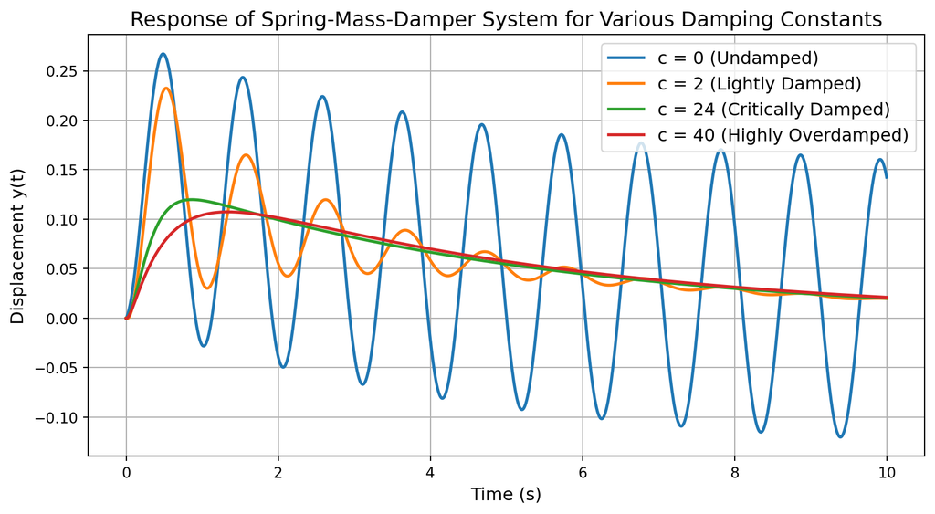

```python
import numpy as np
import matplotlib.pyplot as plt

# Define time range
t = np.linspace(0, 10, 1000)

# Solutions for different damping constants

# Case 1: c = 0 (Undamped System)
y_c0 = 0.1387 * np.exp(-0.2 * t) -0.1387 * np.cos(6 * t) +0.0277 * np.sin(6 * t)

# Case 2: c = 2 (Lightly Damped System)
omega_d_c2 = np.sqrt(143)/2  # Approximately 5.9792
y_c2 = 0.1393 * np.exp(-0.2 * t) -0.1393 * np.exp(-0.5 * t) * np.cos(omega_d_c2 * t) -0.0186 * np.exp(-0.5 * t) * np.sin(omega_d_c2 * t)

# Case 3: c = 24 (Critically Damped System)
y_c24 = 0.1484 * np.exp(-0.2 * t) -0.1484 * np.exp(-6 * t) -0.861 * t * np.exp(-6 * t)

# Case 4: c = 40 (Highly Overdamped System)
y_c40 = 0.156 * np.exp(-0.2 * t) -0.1737 * np.exp(-2 * t) +0.0176 * np.exp(-18 * t)

# Plotting
plt.figure(figsize=(9, 5))
plt.plot(t, y_c0, label='c = 0 (Undamped)', linewidth=2)
plt.plot(t, y_c2, label='c = 2 (Lightly Damped)', linewidth=2)
plt.plot(t, y_c24, label='c = 24 (Critically Damped)', linewidth=2)
plt.plot(t, y_c40, label='c = 40 (Highly Overdamped)', linewidth=2)
plt.title('Response of Spring-Mass-Damper System for Various Damping Constants', fontsize=14)
plt.xlabel('Time (s)', fontsize=12)
plt.ylabel('Displacement y(t)', fontsize=12)
plt.legend(fontsize=12)
plt.grid(True)
plt.tight_layout()
plt.show()
```

#### **Visualization Interpretation:**

- **$c = 0$ (Undamped):** Exhibits persistent oscillations with a slight decay due to the forcing function.
- **$c = 2$ (Lightly Damped):** Shows oscillations that gradually decrease in amplitude.
- **$c = 24$ (Critically Damped):** Returns to equilibrium without oscillating, achieving the fastest non-oscillatory return.
- **$c = 40$ (Highly Overdamped):** Returns to equilibrium without oscillating but does so more slowly compared to the critically damped case.

**Final Answer:**

For each damping constant $c$, the solution $y(t)$ is:

1. **Undamped ($c = 0$):**
   $$y(t) = 0.1387 e^{-0.2 t} -0.1387 \cos(6t) +0.0277 \sin(6t)$$
2. **Lightly Damped ($c = 2$):**
   $$y(t) = 0.1393 e^{-0.2 t} -0.1393 e^{-0.5 t} \cos(5.9792 t) -0.0186 e^{-0.5 t} \sin(5.9792 t)$$
3. **Critically Damped ($c = 24$):**
   $$y(t) = 0.1484 e^{-0.2 t} -0.1484 e^{-6 t} -0.861 t e^{-6 t}$$
4. **Highly Overdamped ($c = 40$):**
   $$y(t) = 0.156 e^{-0.2 t} -0.1737 e^{-2 t} +0.0176 e^{-18 t}$$

# SECTION 5.6

**Assigned:** 1, 3, 6**

**5.6.1**

### **Problem:**

### **Solution:**

**5.6.3**

### **Problem:**

### **Solution:**

**5.6.6**

### **Problem:**

### **Solution:**

# SECTION 8.2

**Assigned:** 1, 3, 5, 7, 18, 19**

**8.2.1**

### **Problem:**

Determine the radius of convergence and interval of convergence for the power series:

$$\sum_{n=1}^\infty \frac{t^n}{n}$$

### **Solution:**

#### **Apply the Ratio Test**

The general term of the series is:

$$a_n = \frac{t^n}{n}$$

The Ratio Test involves evaluating the limit:

$$L = \lim_{n \to \infty} \bigg| \frac{a_{n+1}}{a_n} \bigg|$$

Substitute $a_n = \frac{t^n}{n}$ and $a_{n+1} = \frac{t^{n+1}}{n+1}$:

$$\frac{a_{n+1}}{a_n} = \frac{\frac{t^{n+1}}{n+1}}{\frac{t^n}{n}} = \frac{t^{n+1}}{n+1} \cdot \frac{n}{t^n} = \frac{t \cdot n}{n+1}$$

Take the limit as $n \to \infty$:

$$L = \lim_{n \to \infty} \frac{t \cdot n}{n+1}$$

Factor $n$ in the denominator:

$$L = \lim_{n \to \infty} \frac{t}{1 + \frac{1}{n}}$$

As $n \to \infty$, $\frac{1}{n} \to 0$, so:

$$L = |t|$$

#### **Convergence Criterion**

The Ratio Test states that the series converges absolutely when:

$$L < 1 \quad \longrightarrow \quad |t| < 1$$

The series diverges when:

$$L > 1 \quad \longrightarrow \quad |t| > 1$$

Therefore, the radius of convergence is:

$$R = 1$$

#### **Endpoint Analysis**

Test the behavior of the series at the endpoints $t = -1$ and $t = 1$.

- **Case $t = 1$:**  
  Substituting $t = 1$, the series becomes:

  $$\sum_{n=1}^\infty \frac{1}{n}$$

  which is the harmonic series. The harmonic series **diverges**.
- **Case $t = -1$:**  
  Substituting $t = -1$, the series becomes:

  $$\sum_{n=1}^\infty \frac{(-1)^n}{n}$$

  By the Alternating Series Test, this series **converges conditionally**.

#### **Interval of Convergence**

$$-1 \leq t < 1$$

**Final Answer:**

**Radius of Convergence:**

$$R = 1$$

**Interval of Convergence:**

$$-1 \leq t < 1$$

**8.2.3**

### **Problem:**

Determine the radius of convergence and interval of convergence for the power series:

$$\sum_{n=1}^\infty \frac{n^2 (t - 2)^n}{5^n}$$

### **Solution:**

#### **Apply the Ratio Test**

The general term of the series is:

$$a_n = \frac{n^2 (t - 2)^n}{5^n}$$

The Ratio Test involves evaluating the limit:

$$L = \lim_{n \to \infty} \bigg| \frac{a_{n+1}}{a_n} \bigg|$$

Substitute $a_n = \frac{n^2 (t - 2)^n}{5^n}$ and $a_{n+1} = \frac{(n+1)^2 (t - 2)^{n+1}}{5^{n+1}}$:

$$\frac{\frac{(n+1)^2 (t - 2)^{n+1}}{5^{n+1}}}{\frac{n^2 (t - 2)^n}{5^n}} = \frac{(n+1)^2 (t - 2)^{n+1} \cdot 5^n}{n^2 (t - 2)^n \cdot 5^{n+1}}$$

$$= \frac{(n+1)^2}{n^2} \cdot \frac{|t - 2|}{5}$$

#### **Simplify the Limit**

$$L = \lim_{n \to \infty} \frac{(n+1)^2}{n^2} \cdot \frac{|t - 2|}{5}$$

Expand $(n+1)^2$ and divide by $n^2$:

$$\frac{(n+1)^2}{n^2} = \frac{n^2 + 2n + 1}{n^2} = 1 + \frac{2}{n} + \frac{1}{n^2}$$

As $n \to \infty$, $\frac{2}{n} \to 0$ and $\frac{1}{n^2} \to 0$, so:

$$\lim_{n \to \infty} \frac{(n+1)^2}{n^2} = 1$$

Therefore:

$$L = \frac{|t - 2|}{5}$$

#### **Convergence Criterion**

The Ratio Test states that the series converges absolutely when:

$$L < 1 \quad \longrightarrow \quad \frac{|t - 2|}{5} < 1$$

Multiply through by $5$:

$$|t - 2| < 5$$

This inequality gives:

$$-5 < t - 2 < 5$$

Add $2$ to all sides:

$$-3 < t < 7$$

Thus, the radius of convergence is:

$$R = 5$$

#### **Endpoint Analysis**

We now test the behavior of the series at the endpoints $t = -3$ and $t = 7$.

- **Case $t = -3$:**  
  Substituting $t = -3$, the series becomes:

  $$\sum_{n=1}^\infty \frac{n^2 (-1)^n}{1}$$

  This series does not converge because the terms $\frac{n^2 (-1)^n}{1}$ do not approach $0$ as $n \to \infty$.
- **Case $t = 7$:**
  Substituting $t = 7$, the series becomes:
  $$\sum_{n=1}^\infty n^2$$
  This series diverges because $n^2$ grows without bound as $n \to \infty$.

#### **Interval of Convergence**

Since the series diverges at both endpoints, the interval of convergence is:

$$-3 < t < 7$$

**Final Answer:**

**Radius of Convergence:**

$$R = 5$$

**Interval of Convergence:**

$$-3 < t < 7$$

**8.2.5**

### **Problem:**

Find the first four nonzero coefficients of the Taylor series expansion for the function

$$f(t) = \sqrt{1 + t}$$

about $a = 0$. In addition, state the radius of convergence of the series expansion.

### **Solution:**

#### **Rewrite the Function**

The function is expressed as:

$$f(t) = \sqrt{t + 1}$$

This can be rewritten as:

$$f(t) = (1 + t)^{1/2}$$

The known power series expansion for $(1 + x)^k$ for $|x| < 1$ is used:

$$(1 + x)^k = \sum_{n=0}^\infty \frac{\prod_{j=0}^{n-1} (k - j)}{n!} x^n$$

Here, $k = \frac{1}{2}$ and $x = t$.

#### **General Formula for Coefficients**

The general term for the Taylor series expansion is given by:

$$a_n = \frac{\prod_{j=0}^{n-1} \left(\frac{1}{2} - j\right)}{n!}$$

#### **Compute the First Four Nonzero Coefficients**

1. **For $n = 0$:**

$$a_0 = \frac{\prod_{j=0}^{-1} \left(\frac{1}{2} - j\right)}{0!} = 1$$

The first term is:

$$a_0 t^0 = 1$$

2. **For $n = 1$:**

$$a_1 = \frac{\prod_{j=0}^{0} \left(\frac{1}{2} - j\right)}{1!} = \frac{\frac{1}{2}}{1!} = \frac{1}{2}$$

The second term is:

$$a_1 t^1 = \frac{1}{2}t$$

3. **For $n = 2$:**

$$a_2 = \frac{\prod_{j=0}^{1} \left(\frac{1}{2} - j\right)}{2!} = \frac{\left(\frac{1}{2}\right)\left(\frac{1}{2} - 1\right)}{2!} = \frac{\frac{1}{2} \cdot -\frac{1}{2}}{2} = -\frac{1}{8}$$

The third term is:

$$a_2 t^2 = -\frac{1}{8}t^2$$

4. **For $n = 3$:**

$$a_3 = \frac{\prod_{j=0}^{2} \left(\frac{1}{2} - j\right)}{3!} = \frac{\left(\frac{1}{2}\right)\left(\frac{1}{2} - 1\right)\left(\frac{1}{2} - 2\right)}{3!}$$

Simplify:

$$a_3 = \frac{\left(\frac{1}{2}\right)\left(-\frac{1}{2}\right)\left(-\frac{3}{2}\right)}{6} = \frac{\frac{3}{8}}{6} = \frac{1}{16}$$

The fourth term is:

$$a_3 t^3 = \frac{1}{16}t^3$$

#### **The Taylor Series**

The first four nonzero terms of the Taylor series expansion are:

$$f(t) = 1 + \frac{1}{2}t - \frac{1}{8}t^2 + \frac{1}{16}t^3 + \cdots$$

#### **Radius of Convergence**

The power series for $(1 + x)^k$ converges for $|x| < 1$. Substituting $x = t$, the series converges for $|t| < 1$. The radius of convergence is therefore:

$$R = 1$$

**Final Answer:**

**First Four Nonzero Terms:**

$$f(t) = 1 + \frac{1}{2}t - \frac{1}{8}t^2 + \frac{1}{16}t^3$$

**Radius of Convergence:**

$$R = 1$$

**8.2.7**

### **Problem:**

Find the first four nonzero coefficients of the Taylor series expansion for the function

$$f(t) = \frac{1}{1 + t^4}$$

about $a = 0$. In addition, state the radius of convergence of the series expansion.

### **Solution:**

#### **Rewrite the Function**

The function is expressed as:

$$f(t) = \frac{1}{1 + t^4}$$

This can be rewritten in a form suitable for a geometric series expansion:

$$f(t) = \frac{1}{1 - (-t^4)}$$

The known power series expansion for $\frac{1}{1 - x}$ is:

$$\frac{1}{1 - x} = \sum_{n=0}^\infty x^n, \quad \text{for } |x| < 1$$

Substituting $x = -t^4$, the series becomes:

$$f(t) = \sum_{n=0}^\infty (-t^4)^n$$

#### **General Formula for the Terms**

The general term of the series is:

$$a_n = (-1)^n t^{4n}$$

#### **Compute the First Four Nonzero Terms**

1. **For $n = 0$:**

$$a_0 = (-1)^0 t^{4 \cdot 0} = 1$$

The first term is:

$$a_0 = 1$$

2. **For $n = 1$:**

$$a_1 = (-1)^1 t^{4 \cdot 1} = -t^4$$

The second term is:

$$a_1 = -t^4$$

3. **For $n = 2$:**

$$a_2 = (-1)^2 t^{4 \cdot 2} = t^8$$

The third term is:

$$a_2 = t^8$$

4. **For $n = 3$:**

$$a_3 = (-1)^3 t^{4 \cdot 3} = -t^{12}$$

The fourth term is:

$$a_3 = -t^{12}$$

#### **The Taylor Series**

The first four nonzero terms of the Taylor series expansion are:

$$f(t) = 1 - t^4 + t^8 - t^{12} + \cdots$$

#### **Radius of Convergence**

The geometric series $\frac{1}{1 - x}$ converges for $|x| < 1$. Substituting $x = -t^4$, the series converges for:

$$|-t^4| < 1 \quad \implies \quad |t^4| < 1 \quad \implies \quad |t| < 1$$

Thus, the radius of convergence is:

$$R = 1$$

**Final Answer:**

**First Four Nonzero Terms:**

$$f(t) = 1 - t^4 + t^8 - t^{12}$$

**Radius of Convergence:**

$$R = 1$$

**8.2.18**

### **Problem:**

Find the first four nonzero coefficients of the Taylor series expansion for the integral:

$$\int_0^t \frac{1}{1 + s^4} \, ds$$

by first expanding the integrand into its Taylor series and then integrating term by term.

### **Solution:**

#### **Expand the Integrand**

The given integrand is:

$$\frac{1}{1 + s^4}$$

Using the result from the previous problem, the Taylor series expansion for $\frac{1}{1 + s^4}$ is:

$$\frac{1}{1 + s^4} = \sum_{n=0}^\infty (-1)^n s^{4n}$$

The first several terms of this series are:

$$\frac{1}{1 + s^4} = 1 - s^4 + s^8 - s^{12} + \cdots$$

#### **Integrate Term by Term**

The integral is:

$$\int_0^t \frac{1}{1 + s^4} \, ds = \int_0^t \left(1 - s^4 + s^8 - s^{12} + \cdots \right) \, ds$$

Integrating each term of the series:

1. **First term:**

$$\int_0^t 1 \, ds = t$$

2. **Second term:**

$$\int_0^t -s^4 \, ds = -\frac{s^5}{5} \bigg|_0^t = -\frac{t^5}{5}$$

3. **Third term:**

$$\int_0^t s^8 \, ds = \frac{s^9}{9} \bigg|_0^t = \frac{t^9}{9}$$

4. **Fourth term:**

$$\int_0^t -s^{12} \, ds = -\frac{s^{13}}{13} \bigg|_0^t = -\frac{t^{13}}{13}$$

#### **Combine the Results**

The first four nonzero terms of the Taylor series expansion for the integral are:

$$\int_0^t \frac{1}{1 + s^4} \, ds = t - \frac{t^5}{5} + \frac{t^9}{9} - \frac{t^{13}}{13} + \cdots$$

**Final Answer:**

The Taylor series expansion for the integral is:

$$\int_0^t \frac{1}{1 + s^4} \, ds = t - \frac{t^5}{5} + \frac{t^9}{9} - \frac{t^{13}}{13} + \cdots$$

**8.2.19**

### **Problem:**

Find the first four nonzero coefficients of the Taylor series expansion for the integral:

$$\int_0^t e^{-s^2} \, ds$$

by first expanding the integrand into its Taylor series and then integrating term by term.

### **Solution:**

#### **Expand the Integrand**

The given integrand is:

$$e^{-s^2}$$

The Taylor series expansion for $e^x$ is:

$$e^x = \sum_{n=0}^\infty \frac{x^n}{n!}$$

Substituting $x = -s^2$, the expansion becomes:

$$e^{-s^2} = \sum_{n=0}^\infty \frac{(-1)^n s^{2n}}{n!}$$

The first few terms are:

$$e^{-s^2} = 1 - s^2 + \frac{s^4}{2!} - \frac{s^6}{3!} + \cdots$$

#### **Integrate Term by Term**

The integral is:

$$\int_0^t e^{-s^2} \, ds = \int_0^t \left(1 - s^2 + \frac{s^4}{2} - \frac{s^6}{6} + \cdots \right) \, ds$$

Integrating each term of the series:

1. **First term:**

$$\int_0^t 1 \, ds = t$$

2. **Second term:**

$$\int_0^t -s^2 \, ds = -\frac{s^3}{3} \bigg|_0^t = -\frac{t^3}{3}$$

3. **Third term:**

$$\int_0^t \frac{s^4}{2} \, ds = \frac{1}{2} \cdot \frac{s^5}{5} \bigg|_0^t = \frac{t^5}{10}$$

4. **Fourth term:**

$$\int_0^t -\frac{s^6}{6} \, ds = -\frac{1}{6} \cdot \frac{s^7}{7} \bigg|_0^t = -\frac{t^7}{42}$$

#### **Combine the Results**

The first four nonzero terms of the Taylor series expansion for the integral are:

$$\int_0^t e^{-s^2} \, ds = t - \frac{t^3}{3} + \frac{t^5}{10} - \frac{t^7}{42} + \cdots$$

**Final Answer:**

The Taylor series expansion for the integral is:

$$\int_0^t e^{-s^2} \, ds = t - \frac{t^3}{3} + \frac{t^5}{10} - \frac{t^7}{42} + \cdots$$

# SECTION 8.3

**Assigned:** 1, 2, 3, 9, 15, 16, 17**

**8.3.1**

### **Problem:**

Find the first four terms in the Taylor series representation of the general solution for the following DE:

$$y'' + t y' = 0$$

### **Solution:**

#### **Assume a Taylor Series Solution**

Assume the solution $y(t)$ is given by a Taylor series:

$$y(t) = \sum_{n=0}^\infty a_n t^n$$

where $a_n$ are coefficients to be determined. The derivatives are:

1. **First derivative**:

   $$y'(t) = \sum_{n=1}^\infty n a_n t^{n-1}$$
2. **Second derivative**:
   $$y''(t) = \sum_{n=2}^\infty n(n-1)a_n t^{n-2}$$

#### **Substitute Into the Differential Equation**

Substitute $y(t)$, $y'(t)$, and $y''(t)$ into the equation $y'' + t y' = 0$:

$$\sum_{n=2}^\infty n(n-1)a_n t^{n-2} + t \sum_{n=1}^\infty n a_n t^{n-1} = 0$$

#### **Simplify each term:**

1. **First term:**

   $$\sum_{n=2}^\infty n(n-1)a_n t^{n-2}$$

   To match powers of $t$, substitute $m = n-2$, so $n = m+2$, and $t^{n-2} \to t^m$:

   $$\sum_{n=2}^\infty n(n-1)a_n t^{n-2} = \sum_{m=0}^\infty (m+2)(m+1)a_{m+2} t^m$$
2. **Second term:**
   $$t \sum_{n=1}^\infty n a_n t^{n-1}$$
   Multiplying $t$ by $t^{n-1}$ raises the power to $t^n$:
   $$t \sum_{n=1}^\infty n a_n t^{n-1} = \sum_{n=1}^\infty n a_n t^n$$

#### **Combine the Two Terms**

The equation now becomes:

$$\sum_{m=0}^\infty (m+2)(m+1)a_{m+2} t^m + \sum_{n=1}^\infty n a_n t^n = 0$$

Separate the $m = 0$ term from the first summation:

1. **For $m = 0$:**

   $$(m+2)(m+1)a_{m+2} = 2 \cdot 1 \cdot a_2 = 2a_2$$
2. **For $m \geq 1$:**
   $$(m+2)(m+1)a_{m+2} + m a_m = 0$$

Thus, the equation splits into:

1. **Constant term:**

   $$2a_2 = 0 \quad \implies \quad a_2 = 0$$
2. **Recursive relation:**
   $$a_{m+2} = -\frac{m a_m}{(m+2)(m+1)}$$

#### **Solve for the Coefficients**

Start with $a_0$ and $a_1$ as arbitrary constants:

$$a_0 = C_0, \quad a_1 = C_1$$

Use the recurrence relation to find the higher coefficients:

1. **For $m = 0$:**

   $$a_2 = 0$$
2. **For $m = 1$:**

   $$a_3 = -\frac{1 \cdot a_1}{(1+2)(1+1)} = -\frac{a_1}{6}$$
3. **For $m = 2$:**

   $$a_4 = 0 \quad \text{(since $a_2 = 0$)}$$
4. **For $m = 3$:**
   $$a_5 = -\frac{3 \cdot a_3}{(3+2)(3+1)} = -\frac{3 \cdot \left(-\frac{a_1}{6}\right)}{20} = \frac{a_1}{40}$$

#### **Write the Taylor Series Solution**

Substitute the coefficients into the Taylor series:

$$y(t) = a_0 + a_1 t + a_2 t^2 + a_3 t^3 + a_4 t^4 + a_5 t^5 + \cdots$$

Using the computed values:

$$y(t) = C_0 + C_1 t - \frac{C_1}{6} t^3 + \frac{C_1}{40} t^5 + \cdots$$

**Final Answer:**

The first four terms of the Taylor series representation for the solution are:

$$y(t) = C_0 + C_1 t - \frac{C_1}{6} t^3 + \frac{C_1}{40} t^5$$

**8.3.2**

### **Problem:**

Find the first four terms in the Taylor series representation of the general solution for the following DE:

$$y'' + 4y' = 0$$

### **Solution:**

#### **Assume a Taylor Series Solution**

Assume the solution $y(t)$ is given by a Taylor series:

$$y(t) = \sum_{n=0}^\infty a_n t^n$$

where $a_n$ are coefficients to be determined. The derivatives are:

1. **First derivative**:

   $$y'(t) = \sum_{n=1}^\infty n a_n t^{n-1}$$
2. **Second derivative**:
   $$y''(t) = \sum_{n=2}^\infty n(n-1)a_n t^{n-2}$$

#### **Substitute Into the Differential Equation**

Substitute $y(t)$, $y'(t)$, and $y''(t)$ into the equation $y'' + 4y' = 0$:

$$\sum_{n=2}^\infty n(n-1)a_n t^{n-2} + 4 \sum_{n=1}^\infty n a_n t^{n-1} = 0$$

#### **Simplify each term:**

1. **First term** ($y''(t)$):

   $$\sum_{n=2}^\infty n(n-1)a_n t^{n-2}$$

   Use the substitution $m = n-2$, so $n = m+2$, and $t^{n-2} \to t^m$:

   $$\sum_{n=2}^\infty n(n-1)a_n t^{n-2} = \sum_{m=0}^\infty (m+2)(m+1)a_{m+2} t^m$$
2. **Second term** ($4y'(t)$):
   $$4 \sum_{n=1}^\infty n a_n t^{n-1}$$
   Multiplying by $t$ raises the power to $t^m$:
   $$4 \sum_{n=1}^\infty n a_n t^{n-1} = 4 \sum_{m=0}^\infty (m+1) a_{m+1} t^m$$

#### **Combine the Two Terms**

The equation becomes:

$$\sum_{m=0}^\infty (m+2)(m+1)a_{m+2} t^m + 4 \sum_{m=0}^\infty (m+1)a_{m+1} t^m = 0$$

Combine terms with the same powers of $t$:

$$\sum_{m=0}^\infty \left[(m+2)(m+1)a_{m+2} + 4(m+1)a_{m+1}\right] t^m = 0$$

Since this must hold for all $t^m$, the coefficients of $t^m$ must satisfy:

$$(m+2)(m+1)a_{m+2} + 4(m+1)a_{m+1} = 0$$

Factor out $(m+1)$:

$$(m+1)\left[(m+2)a_{m+2} + 4a_{m+1}\right] = 0$$

For $m \geq 0$, this gives the **recurrence relation**:

$$a_{m+2} = -\frac{4a_{m+1}}{m+2}$$

#### **Solve for the Coefficients**

Start with $a_0$ and $a_1$ as arbitrary constants:

$$a_0 = C_0, \quad a_1 = C_1$$

Use the recurrence relation to find the higher coefficients:

1. **For $m = 0$:**

   $$a_2 = -\frac{4a_1}{0+2} = -\frac{2a_1}{1} = -2a_1$$
2. **For $m = 1$:**

   $$a_3 = -\frac{4a_2}{1+2} = -\frac{4(-2a_1)}{3} = \frac{8a_1}{3}$$
3. **For $m = 2$:**

   $$a_4 = -\frac{4a_3}{2+2} = -\frac{4\left(\frac{8a_1}{3}\right)}{4} = -\frac{8a_1}{3}$$
4. **For $m = 3$:**
   $$a_5 = -\frac{4a_4}{3+2} = -\frac{4\left(-\frac{8a_1}{3}\right)}{5} = \frac{32a_1}{15}$$

#### **Write the Taylor Series Solution**

Substitute the coefficients into the Taylor series:

$$y(t) = a_0 + a_1 t + a_2 t^2 + a_3 t^3 + a_4 t^4 + a_5 t^5 + \cdots$$

Using the computed values:

$$y(t) = C_0 + C_1 t - 2C_1 t^2 + \frac{8C_1}{3}t^3 - \frac{8C_1}{3}t^4 + \frac{32C_1}{15}t^5 + \cdots$$

**Final Answer:**

The first four terms of the Taylor series representation for the solution are:

$$y(t) = C_0 + C_1 t - 2C_1 t^2 + \frac{8C_1}{3}t^3$$

**8.3.3**

### **Problem:**

Find the first four terms in the Taylor series representation of the general solution for the following DE:

$$y'' + 4y = 0$$

### **Solution:**

#### **Assume a Taylor Series Solution**

Assume the solution $y(t)$ is given by a Taylor series:

$$y(t) = \sum_{n=0}^\infty a_n t^n$$

where $a_n$ are coefficients to be determined. The derivatives are:

1. **First derivative**:

   $$y'(t) = \sum_{n=1}^\infty n a_n t^{n-1}$$
2. **Second derivative**:
   $$y''(t) = \sum_{n=2}^\infty n(n-1)a_n t^{n-2}$$

#### **Substitute Into the Differential Equation**

Substitute $y(t)$ and $y''(t)$ into the equation $y'' + 4y = 0$:

$$\sum_{n=2}^\infty n(n-1)a_n t^{n-2} + 4 \sum_{n=0}^\infty a_n t^n = 0$$

#### **Simplify Each Term:**

1. **First term ($y''(t)$):**

   $$\sum_{n=2}^\infty n(n-1)a_n t^{n-2}$$

   Use the substitution $m = n-2$, so $n = m+2$, and $t^{n-2} \to t^m$:

   $$\sum_{n=2}^\infty n(n-1)a_n t^{n-2} = \sum_{m=0}^\infty (m+2)(m+1)a_{m+2} t^m$$
2. **Second term ($4y(t)$):**
   $$4 \sum_{n=0}^\infty a_n t^n$$

#### **Combine the Two Terms**

The equation becomes:

$$\sum_{m=0}^\infty (m+2)(m+1)a_{m+2} t^m + 4 \sum_{m=0}^\infty a_m t^m = 0$$

Combine terms with the same powers of $t^m$:

$$\sum_{m=0}^\infty \left[(m+2)(m+1)a_{m+2} + 4a_m\right] t^m = 0$$

Since this must hold for all $t^m$, the coefficients of $t^m$ must satisfy:

$$(m+2)(m+1)a_{m+2} + 4a_m = 0$$

#### **Solve for the Coefficients**

The recurrence relation is:

$$a_{m+2} = -\frac{4a_m}{(m+2)(m+1)}$$

Start with $a_0$ and $a_1$ as arbitrary constants:

$$a_0 = C_0, \quad a_1 = C_1$$

Use the recurrence relation to compute the higher coefficients:

1. **For $m = 0$:**

   $$a_2 = -\frac{4a_0}{(0+2)(0+1)} = -\frac{4a_0}{2} = -2a_0$$
2. **For $m = 1$:**

   $$a_3 = -\frac{4a_1}{(1+2)(1+1)} = -\frac{4a_1}{6} = -\frac{2a_1}{3}$$
3. **For $m = 2$:**

   $$a_4 = -\frac{4a_2}{(2+2)(2+1)} = -\frac{4(-2a_0)}{12} = \frac{8a_0}{12} = \frac{2a_0}{3}$$
4. **For $m = 3$:**
   $$a_5 = -\frac{4a_3}{(3+2)(3+1)} = -\frac{4\left(-\frac{2a_1}{3}\right)}{20} = \frac{8a_1}{60} = \frac{2a_1}{15}$$

#### **Write the Taylor Series Solution**

Substitute the coefficients into the Taylor series:

$$y(t) = a_0 + a_1 t + a_2 t^2 + a_3 t^3 + a_4 t^4 + a_5 t^5 + \cdots$$

Using the computed values:

$$y(t) = C_0 + C_1 t - 2C_0 t^2 - \frac{2C_1}{3} t^3 + \frac{2C_0}{3} t^4 + \frac{2C_1}{15} t^5 + \cdots$$

**Final Answer:**

The first four terms of the Taylor series representation for the solution are:

$$y(t) = C_0 + C_1 t - 2C_0 t^2 - \frac{2C_1}{3} t^3$$

**8.3.9**

### **Problem:**

Find the first four terms in the Taylor series representation of the general solution for the following DE:

$$(1 - t)y'' + y = 0$$

### **Solution:**

#### **Assume a Taylor Series Solution**

Assume the solution $y(t)$ is given by a Taylor series:

$$y(t) = \sum_{n=0}^\infty a_n t^n$$

where $a_n$ are coefficients to be determined. The derivatives are:

1. **First derivative**:

   $$y'(t) = \sum_{n=1}^\infty n a_n t^{n-1}$$
2. **Second derivative**:
   $$y''(t) = \sum_{n=2}^\infty n(n-1)a_n t^{n-2}$$

#### **Substitute Into the Differential Equation**

Substitute $y(t)$ and $y''(t)$ into the equation $(1 - t)y'' + y = 0$:

$$(1 - t) \sum_{n=2}^\infty n(n-1)a_n t^{n-2} + \sum_{n=0}^\infty a_n t^n = 0$$

#### **Expand and Simplify Each Term:**

1. **First term** ($(1 - t)y''(t)$):

Expand $(1 - t)y''(t)$:

$$(1 - t)y''(t) = \sum_{n=2}^\infty n(n-1)a_n t^{n-2} - t \sum_{n=2}^\infty n(n-1)a_n t^{n-2}$$

Simplify:

- The first part ($1 \cdot y''$):

  $$\sum_{n=2}^\infty n(n-1)a_n t^{n-2}$$
- The second part ($-t \cdot y''$):
  $$-\sum_{n=2}^\infty n(n-1)a_n t^{n-1}$$

Reindex the second part to align powers of $t$. Let $m = n - 1$, so $n = m + 1$ and $t^{n-1} = t^m$:

$$-\sum_{n=2}^\infty n(n-1)a_n t^{n-1} = -\sum_{m=1}^\infty (m+1)m a_{m+1} t^m$$

Thus, $(1 - t)y''(t)$ becomes:

$$\sum_{n=2}^\infty n(n-1)a_n t^{n-2} - \sum_{m=1}^\infty (m+1)m a_{m+1} t^m$$

1. **Second term** ($y(t)$):

$$\sum_{n=0}^\infty a_n t^n$$

#### **Combine the Two Terms**

Now combine all terms into a single summation:

$$\sum_{n=2}^\infty n(n-1)a_n t^{n-2} - \sum_{m=1}^\infty (m+1)m a_{m+1} t^m + \sum_{n=0}^\infty a_n t^n = 0$$

Reindex the first term ($t^{n-2}$) to match the powers of $t^m$. Let $m = n - 2$, so $n = m + 2$ and $t^{n-2} = t^m$:

$$\sum_{n=2}^\infty n(n-1)a_n t^{n-2} = \sum_{m=0}^\infty (m+2)(m+1)a_{m+2} t^m$$

Thus, the equation becomes:

$$\sum_{m=0}^\infty (m+2)(m+1)a_{m+2} t^m - \sum_{m=1}^\infty (m+1)m a_{m+1} t^m + \sum_{m=0}^\infty a_m t^m = 0$$

Combine terms:

$$\sum_{m=0}^\infty \left[(m+2)(m+1)a_{m+2} - (m+1)m a_{m+1} + a_m\right] t^m = 0$$

#### **Solve for the Recurrence Relation**

For the equation to hold for all $t^m$, the coefficients of $t^m$ must equal zero:

$$(m+2)(m+1)a_{m+2} - (m+1)m a_{m+1} + a_m = 0$$

Simplify:

$$(m+2)(m+1)a_{m+2} = (m+1)m a_{m+1} - a_m$$

Divide through by $(m+2)(m+1)$:

$$a_{m+2} = \frac{(m+1)m a_{m+1} - a_m}{(m+2)(m+1)}$$

#### **Solve for the Coefficients**

Start with $a_0$ and $a_1$ as arbitrary constants:

$$a_0 = C_0, \quad a_1 = C_1$$

Use the recurrence relation to compute the higher coefficients:

1. **For $m = 0$:**

   $$a_2 = \frac{(0+1)0 a_1 - a_0}{(0+2)(0+1)} = \frac{-a_0}{2}$$
2. **For $m = 1$:**

   $$a_3 = \frac{(1+1)1 a_2 - a_1}{(1+2)(1+1)} = \frac{2 a_2 - a_1}{6}$$

   Substitute $a_2 = -\frac{a_0}{2}$:

   $$a_3 = \frac{2\left(-\frac{a_0}{2}\right) - a_1}{6} = \frac{-a_0 - a_1}{6}$$
3. **For $m = 2$:**
   $$a_4 = \frac{(2+1)2 a_3 - a_2}{(2+2)(2+1)} = \frac{3(2)a_3 - a_2}{12}$$
   Substitute $a_3 = \frac{-a_0 - a_1}{6}$ and $a_2 = -\frac{a_0}{2}$:
   $$a_4 = \frac{6\left(\frac{-a_0 - a_1}{6}\right) - \left(-\frac{a_0}{2}\right)}{12}$$
   Simplify:
   $$a_4 = \frac{-a_0 - a_1 + \frac{a_0}{2}}{12} = \frac{-\frac{a_0}{2} - a_1}{12}$$

#### **Write the Taylor Series Solution**

Substitute the coefficients into the Taylor series:

$$y(t) = a_0 + a_1 t + a_2 t^2 + a_3 t^3 + a_4 t^4 + \cdots$$

Using the computed values:

$$y(t) = C_0 + C_1 t - \frac{C_0}{2} t^2 - \frac{C_0 + C_1}{6} t^3 - \frac{\frac{C_0}{2} + C_1}{12} t^4 + \cdots$$

**Final Answer:**

The first four terms of the Taylor series representation for the solution are:

$$y(t) = C_0 + C_1 t - \frac{C_0}{2} t^2 - \frac{C_0 + C_1}{6} t^3$$

**8.3.15**

### **Problem:**

Find the first four nonzero coefficients of the Taylor series expansion for the solution to the following IVP:

$$y'' + (1 - t)y = 0, \quad y(0) = 1, \quad y'(0) = 0$$

### **Solution:**

#### **Assume a Taylor Series Solution**

Assume the solution $y(t)$ is given by a Taylor series:

$$y(t) = \sum_{n=0}^\infty a_n t^n$$

where $a_n$ are coefficients to be determined. The derivatives are:

1. **First derivative**:

   $$y'(t) = \sum_{n=1}^\infty n a_n t^{n-1}$$
2. **Second derivative**:
   $$y''(t) = \sum_{n=2}^\infty n(n-1)a_n t^{n-2}$$

#### **Substitute Into the Differential Equation**

Substitute $y(t)$ and $y''(t)$ into the equation $y'' + (1 - t)y = 0$:

$$\sum_{n=2}^\infty n(n-1)a_n t^{n-2} + (1 - t)\sum_{n=0}^\infty a_n t^n = 0$$

#### **Expand and Simplify Each Term:**

1. **First term ($y''(t)$):**

   $$\sum_{n=2}^\infty n(n-1)a_n t^{n-2}$$

   Reindex this term by letting $m = n - 2$, so $n = m + 2$, and $t^{n-2} = t^m$:

   $$\sum_{n=2}^\infty n(n-1)a_n t^{n-2} = \sum_{m=0}^\infty (m+2)(m+1)a_{m+2} t^m$$
2. **Second term ($(1 - t)y(t)$):**

   Expand $(1 - t)y(t) = y(t) - t y(t)$:
   - $y(t)$: $\sum_{n=0}^\infty a_n t^n$,
   - $-t y(t)$: Multiply $t$ with $\sum_{n=0}^\infty a_n t^n$:

     $$-t \sum_{n=0}^\infty a_n t^n = \sum_{n=0}^\infty a_n t^{n+1}$$

     Reindex this term by letting $m = n + 1$, so $n = m - 1$, and $t^{n+1} = t^m$:

     $$\sum_{n=0}^\infty a_n t^{n+1} = \sum_{m=1}^\infty a_{m-1} t^m$$

Therefore, the second term becomes:

$$(1 - t)y(t) = \sum_{n=0}^\infty a_n t^n - \sum_{m=1}^\infty a_{m-1} t^m$$

#### **Combine All Terms**

The equation now becomes:

$$\sum_{m=0}^\infty (m+2)(m+1)a_{m+2} t^m + \sum_{n=0}^\infty a_n t^n - \sum_{m=1}^\infty a_{m-1} t^m = 0$$

Align the indices so all terms are in powers of $t^m$:

1. The first summation is:

   $$\sum_{m=0}^\infty (m+2)(m+1)a_{m+2} t^m$$
2. The second summation is:

   $$\sum_{m=0}^\infty a_m t^m$$
3. The third summation is:
   $$-\sum_{m=1}^\infty a_{m-1} t^m$$

Substitute these into the equation:

$$\sum_{m=0}^\infty (m+2)(m+1)a_{m+2} t^m + \sum_{m=0}^\infty a_m t^m - \sum_{m=1}^\infty a_{m-1} t^m = 0$$

#### **Separate the Terms for $m = 0$ and $m \geq 1$:**

For $m = 0$:

$$(0+2)(0+1)a_2 + a_0 = 0 \quad \implies \quad 2a_2 + a_0 = 0 \quad \implies \quad a_2 = -\frac{a_0}{2}$$

For $m \geq 1$:

$$(m+2)(m+1)a_{m+2} + a_m - a_{m-1} = 0$$

#### **Solve for the Coefficients**

From the initial conditions:

$$y(0) = a_0 = 1, \quad y'(0) = a_1 = 0$$

1. **For $m = 0$:**

   $$a_2 = -\frac{a_0}{2} = -\frac{1}{2}$$
2. **For $m = 1$:** Use the recurrence relation:

   $$(1+2)(1+1)a_3 + a_1 - a_0 = 0$$

   Substitute $a_1 = 0$ and $a_0 = 1$:

   $$6a_3 - 1 = 0 \quad \implies \quad a_3 = \frac{1}{6}$$
3. **For $m = 2$:** Use the recurrence relation:
   $$(2+2)(2+1)a_4 + a_2 - a_1 = 0$$
   Substitute $a_2 = -\frac{1}{2}$ and $a_1 = 0$:
   $$12a_4 - \frac{1}{2} = 0 \quad \implies \quad a_4 = \frac{1}{24}$$

#### **Write the Taylor Series Solution**

The coefficients are:

$$a_0 = 1, \quad a_1 = 0, \quad a_2 = -\frac{1}{2}, \quad a_3 = \frac{1}{6}, \quad a_4 = \frac{1}{24}$$

Substitute these into the Taylor series:

$$y(t) = a_0 + a_1 t + a_2 t^2 + a_3 t^3 + a_4 t^4 + \cdots$$

Using the computed coefficients:

$$y(t) = 1 + 0 \cdot t - \frac{1}{2}t^2 + \frac{1}{6}t^3 + \frac{1}{24}t^4 + \cdots$$

**Final Answer:**

The first four nonzero terms of the Taylor series representation for the solution are:

$$y(t) = 1 - \frac{1}{2}t^2 + \frac{1}{6}t^3 + \frac{1}{24}t^4$$

**8.3.16**

### **Problem:**

Find the first four nonzero coefficients of the Taylor series expansion for the solution to the following IVP:

$$y'' - t^2 y' + y \sin t = 0, \quad y(0) = 0, \quad y'(0) = 1,$$

### **Solution:**

#### **Assume a Taylor Series Solution**

Assume the solution $y(t)$ is given by a Taylor series:

$$y(t) = \sum_{n=0}^\infty a_n t^n$$

where $a_n$ are coefficients to be determined. The derivatives are:

1. **First derivative**:

   $$y'(t) = \sum_{n=1}^\infty n a_n t^{n-1}$$
2. **Second derivative**:
   $$y''(t) = \sum_{n=2}^\infty n(n-1)a_n t^{n-2}$$

#### **Substitute Into the Differential Equation**

The equation is:

$$y'' - t^2 y' + y \sin t = 0$$

Substitute $y(t)$, $y'(t)$, $y''(t)$, and the Taylor series expansion for $\sin t = \sum_{k=0}^\infty \frac{(-1)^k t^{2k+1}}{(2k+1)!}$.

1. **Second derivative term ($y''$):**

   $$y''(t) = \sum_{n=2}^\infty n(n-1)a_n t^{n-2}$$
2. **First derivative term ($-t^2 y'$):** Expand $t^2 y'(t)$:

   $$t^2 y'(t) = t^2 \sum_{n=1}^\infty n a_n t^{n-1}$$

   This becomes:

   $$t^2 y'(t) = \sum_{n=1}^\infty n a_n t^{n+1}$$

   Reindex by letting $m = n+1$, so $n = m-1$:

   $$\sum_{n=1}^\infty n a_n t^{n+1} = \sum_{m=2}^\infty (m-1)a_{m-1} t^m$$
3. **Sine term ($y \sin t$):** Multiply $y(t)$ by the Taylor series for $\sin t$:
   $$y(t) \sin t = \left(\sum_{n=0}^\infty a_n t^n\right) \left(\sum_{k=0}^\infty \frac{(-1)^k t^{2k+1}}{(2k+1)!}\right)$$
   Use the Cauchy product formula to expand:
   $$y(t) \sin t = \sum_{m=0}^\infty \left(\sum_{k=0}^m a_{m-k} \frac{(-1)^k}{(2k+1)!}\right) t^m$$
   where the inner summation $k$ sums over all valid indices such that $m - k \geq 0$.

#### **Combine All Terms**

The equation becomes:

$$\sum_{m=0}^\infty (m+2)(m+1)a_{m+2} t^m - \sum_{m=2}^\infty (m-1)a_{m-1} t^m + \sum_{m=0}^\infty \left(\sum_{k=0}^m a_{m-k} \frac{(-1)^k}{(2k+1)!}\right) t^m = 0$$

Since this equation must hold for all powers of $t^m$, the coefficients of $t^m$ must satisfy:

$$(m+2)(m+1)a_{m+2} - (m-1)a_{m-1} + \sum_{k=0}^m a_{m-k} \frac{(-1)^k}{(2k+1)!} = 0$$

#### **Solve for the Coefficients**

From the initial conditions:

1. $y(0) = a_0 = 0$
2. $y'(0) = a_1 = 1$

Now compute higher coefficients using the recurrence relation.

1. **For $m = 0$:**

   $$(0+2)(0+1)a_2 - (0-1)a_{-1} + \sum_{k=0}^0 a_{0-k} \frac{(-1)^k}{(2k+1)!} = 0$$

   This simplifies to:

   $$2a_2 + a_0 \frac{(-1)^0}{1!} = 0$$

   Substitute $a_0 = 0$:

   $$2a_2 = 0 \quad \implies \quad a_2 = 0$$
2. **For $m = 1$:**

   $$(1+2)(1+1)a_3 - (1-1)a_0 + \sum_{k=0}^1 a_{1-k} \frac{(-1)^k}{(2k+1)!} = 0$$

   Simplify:

   $$6a_3 + a_1 \frac{(-1)^0}{1!} + a_0 \frac{(-1)^1}{3!} = 0$$

   Substitute $a_0 = 0$ and $a_1 = 1$:

   $$6a_3 + 1 = 0 \quad \implies \quad a_3 = -\frac{1}{6}$$
3. **For $m = 2$:**

   $$(2+2)(2+1)a_4 - (2-1)a_1 + \sum_{k=0}^2 a_{2-k} \frac{(-1)^k}{(2k+1)!} = 0$$

   Simplify:

   $$12a_4 - 1 + a_2 \frac{(-1)^0}{1!} + a_1 \frac{(-1)^1}{3!} + a_0 \frac{(-1)^2}{5!} = 0$$

   Substitute $a_0 = 0$, $a_1 = 1$, and $a_2 = 0$:

   $$12a_4 - 1 - \frac{1}{6} = 0 \quad \implies \quad 12a_4 = \frac{7}{6} \quad \implies \quad a_4 = \frac{7}{72}$$
4. **For $m = 3$:** Follow a similar process to find $a_5$, using previous coefficients.

#### **Write the Taylor Series Solution**

The coefficients are:

$$a_0 = 0, \quad a_1 = 1, \quad a_2 = 0, \quad a_3 = -\frac{1}{6}, \quad a_4 = \frac{7}{72}$$

Substitute these into the Taylor series:

$$y(t) = a_0 + a_1 t + a_2 t^2 + a_3 t^3 + a_4 t^4 + \cdots$$

Using the computed coefficients:

$$y(t) = t - \frac{1}{6}t^3 + \frac{7}{72}t^4 + \cdots$$

**Final Answer:**

**8.3.17**

### **Problem:**

Find the first four nonzero coefficients of the Taylor series expansion for the solution to the following IVP:

$$y' + y \sin t = 0, \quad y(0) = 1, \quad y'(0) = 0$$

### **Solution:**

#### **Assume a Taylor Series Solution**

Assume the solution $y(t)$ is given by a Taylor series:

$$y(t) = \sum_{n=0}^\infty a_n t^n$$

where $a_n$ are coefficients to be determined. The derivative is:

1. **First derivative**:
   $$y'(t) = \sum_{n=1}^\infty n a_n t^{n-1}$$

The sine function is expanded as a Taylor series:

$$\sin t = \sum_{k=0}^\infty \frac{(-1)^k t^{2k+1}}{(2k+1)!}$$

#### **Substitute Into the Differential Equation**

The equation is:

$$y' + y \sin t = 0$$

Substitute $y(t)$, $y'(t)$, and $\sin t$:

1. **First term ($y'(t)$):**

   $$y'(t) = \sum_{n=1}^\infty n a_n t^{n-1}$$
2. **Second term ($y \sin t$):** Multiply $y(t)$ by $\sin t$:
   $$y(t) \sin t = \left(\sum_{n=0}^\infty a_n t^n\right) \left(\sum_{k=0}^\infty \frac{(-1)^k t^{2k+1}}{(2k+1)!}\right)$$
   Use the Cauchy product formula:
   $$y(t) \sin t = \sum_{m=0}^\infty \left(\sum_{k=0}^m a_{m-k} \frac{(-1)^k}{(2k+1)!}\right) t^m$$
   where the inner summation sums over all valid indices $k$ such that $m - k \geq 0$.

The equation becomes:

$$\sum_{n=1}^\infty n a_n t^{n-1} + \sum_{m=0}^\infty \left(\sum_{k=0}^m a_{m-k} \frac{(-1)^k}{(2k+1)!}\right) t^m = 0$$

#### **Combine All Terms**

Reindex the first summation ($n = 1$) to align powers of $t^m$. Let $m = n-1$, so $n = m+1$:

$$\sum_{n=1}^\infty n a_n t^{n-1} = \sum_{m=0}^\infty (m+1)a_{m+1} t^m$$

The equation now becomes:

$$\sum_{m=0}^\infty \left[(m+1)a_{m+1} + \sum_{k=0}^m a_{m-k} \frac{(-1)^k}{(2k+1)!}\right] t^m = 0$$

For this equation to hold for all powers of $t^m$, the coefficients of $t^m$ must satisfy:

$$(m+1)a_{m+1} + \sum_{k=0}^m a_{m-k} \frac{(-1)^k}{(2k+1)!} = 0$$

#### **Solve for the Coefficients**

From the initial conditions:

$$y(0) = a_0 = 1, \quad y'(0) = a_1 = 0$$

Now compute higher coefficients using the recurrence relation.

1. **For $m = 0$:**

   $$(0+1)a_1 + \sum_{k=0}^0 a_{0-k} \frac{(-1)^k}{(2k+1)!} = 0$$

   Simplify:

   $$a_1 + a_0 \frac{(-1)^0}{1!} = 0$$

   Substitute $a_0 = 1$:

   $$(1+1)a_2 + \sum_{k=0}^1 a_{1-k} \frac{(-1)^k}{(2k+1)!} = 0$$

   Simplify:

   $$2a_2 + a_1 \frac{(-1)^0}{1!} + a_0 \frac{(-1)^1}{3!} = 0$$

   Substitute $a_0 = 1$ and $a_1 = -1$:

   $$2a_2 - 1 - \frac{1}{6} = 0$$

   Simplify:

   $$2a_2 = 1 + \frac{1}{6} = \frac{7}{6} \quad \implies \quad a_2 = \frac{7}{12}$$
3. **For $m = 2$:**

   $$(2+1)a_3 + \sum_{k=0}^2 a_{2-k} \frac{(-1)^k}{(2k+1)!} = 0$$

   Simplify:

   $$3a_3 + a_2 \frac{(-1)^0}{1!} + a_1 \frac{(-1)^1}{3!} + a_0 \frac{(-1)^2}{5!} = 0$$

   Substitute $a_0 = 1$, $a_1 = -1$, and $a_2 = \frac{7}{12}$:

   $$3a_3 + \frac{7}{12} + \frac{1}{6} + \frac{1}{120} = 0$$

   Combine terms:

   $$3a_3 + \frac{70}{120} + \frac{20}{120} + \frac{1}{120} = 0$$

   $$3a_3 + \frac{91}{120} = 0 \quad \implies \quad a_3 = -\frac{91}{360}$$
4. **For $m = 3$:** Compute $a_4$ similarly.

#### **Write the Taylor Series Solution**

The coefficients are:

$$a_0 = 1, \quad a_1 = -1, \quad a_2 = \frac{7}{12}, \quad a_3 = -\frac{91}{360}$$

Substitute these into the Taylor series:

$$y(t) = a_0 + a_1 t + a_2 t^2 + a_3 t^3 + \cdots$$

Using the computed coefficients:

$$y(t) = 1 - t + \frac{7}{12}t^2 - \frac{91}{360}t^3 + \cdots$$

**Final Answer:**

The first four nonzero terms of the Taylor series representation for the solution are:

$$y(t) = 1 - t + \frac{7}{12}t^2 - \frac{91}{360}t^3$$